# Why do Baltic men die earlier?

Life expectancy in the EU, 2015 to 2024

Jolanta Stutane · SZF_184 Data Visualisation and Storytelling

# 1 · The question

9.8 years

That is how much longer Latvian women live than Latvian men, almost twice the EU average.

## The question, and the answer

How much shorter is men’s life expectancy at birth than women’s in the **Baltic states**, compared with the rest of the EU, **2015 to 2024**, and which causes of death go with the gap?

**At the same income, Baltic women live as long as other Europeans. Baltic men live up to 4.6 years shorter.**

# 2 · The data

Six tables, all downloaded by code

## Six tables, downloaded by code

| Table | Source | Raw rows |
| --- | --- | --- |
| Life expectancy at birth, by sex | Eurostat `demo_mlexpec` | 906 |
| Healthy life years, by sex | Eurostat `hlth_hlye` | 618 |
| Deaths under 65, by cause and sex | Eurostat `hlth_cd_asdr2` | 43 902 |
| GDP per capita (EU = 100) | Eurostat `tec00114` | 430 |
| Tertiary education, by sex | Eurostat `sdg_04_20` | 730 |
| Alcohol per person | WHO, via Our World in Data | 4 164 |

Downloaded through the Eurostat API from R, saved untouched in `data/raw/`, documented in `SOURCE.md` (source, link, licence, date).

## What one raw file looks like

| geo | sex | age | TIME_PERIOD | OBS_VALUE | OBS_FLAG |
| --- | --- | --- | --- | --- | --- |
| LV | F | Y_LT1 | 2024 | 81.2 | NA |
| LV | M | Y_LT1 | 2024 | 71.4 | NA |

One row = one country, one sex, one year. `Y_LT1` = age under 1, so life expectancy **at birth**. The gap for Latvia: 81.2 − 71.4 = **9.8 years**.

# 3 · Exploration and preparation

Check every table, then build one panel

## Checking before trusting

**Five checks on every table**

1. Types: numbers are numbers ✓
2. Missing values: counted, never set to 0
3. Ranges: all plausible ✓
4. Duplicates: none ✓
5. Row counts: every EU country complete

**What I found**

- Greece is `EL`, not `GR`
- EU totals and non-EU countries mixed in
- Luxembourg: no healthy years for 2023 and 2024
- Deaths end in 2023
- Alcohol ends in 2020

## Preparing the data for the graph

6 raw  
tables→keep  
27 EU countries→women and men  
side by side→join on  
country and year→gap_panel  
270 rows→2024, ten  
equally rich countries→difference  
from that group

**Why equally rich countries?** The Baltic states are poorer than most of the EU. Comparing with countries of similar income (GDP per person 60 to 90% of the EU average) takes income out of the picture.

# 4 · Building the graph

From a first draft to the final graph

## Version 1: the problem

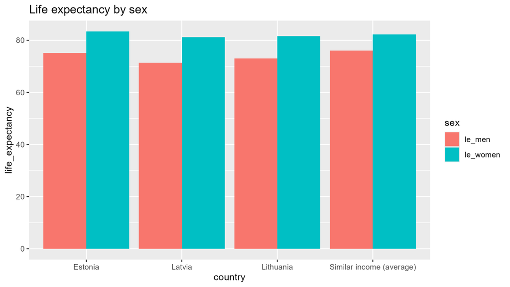

## Version 2: show the difference

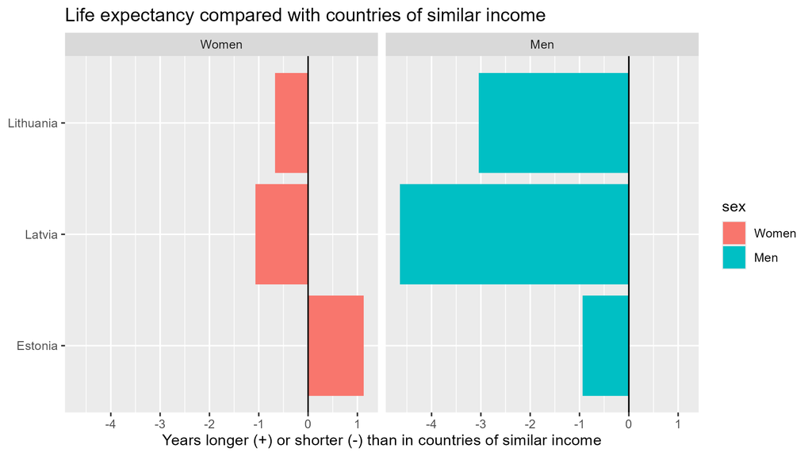

## Refining: the women

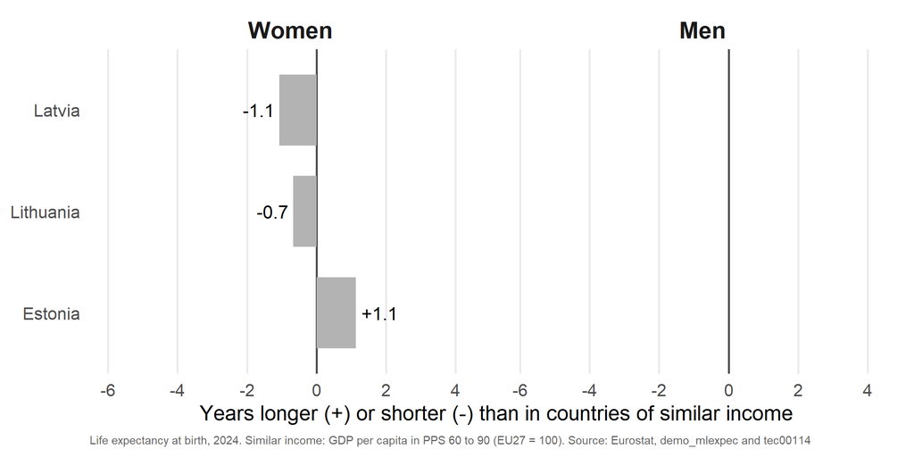

## Refining: the men

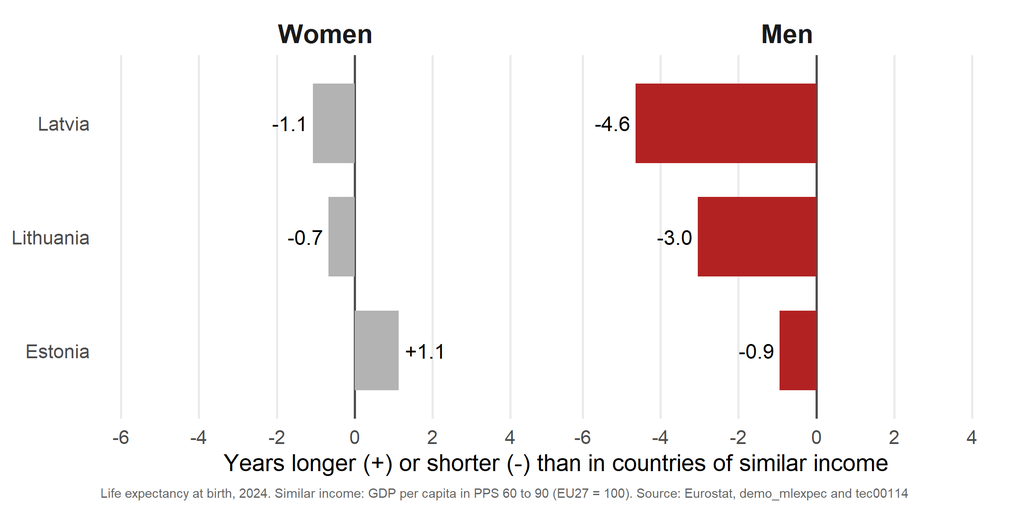

## Refining: one annotation

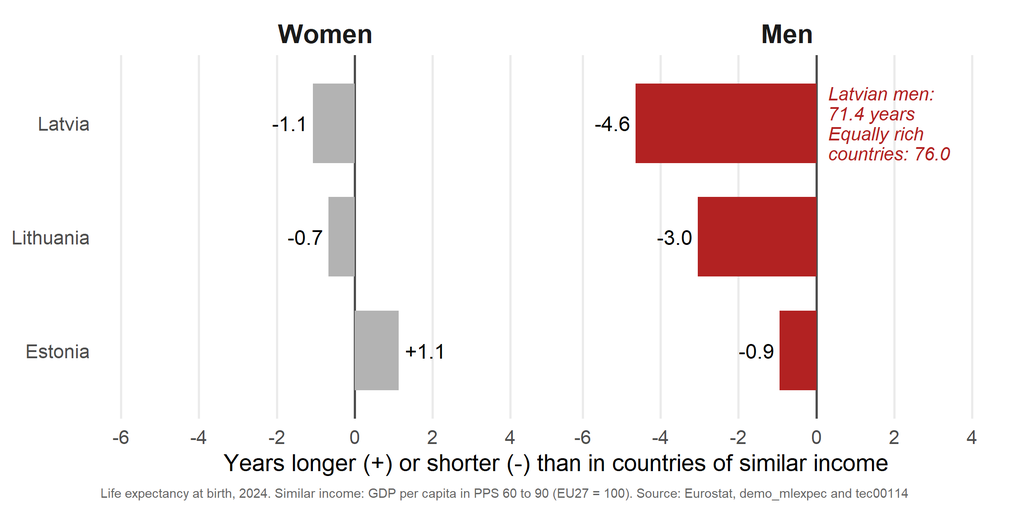

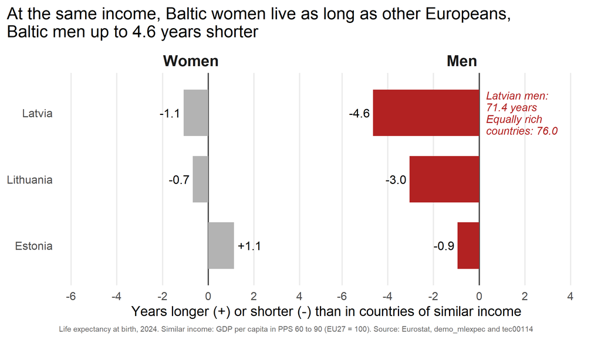

# 5 · The answer

Why the men, and what the data cannot say

## Why the men?

I guessed **heart disease**. That was only half the story.

Baltic men under 65 also die far more often from **external causes**:

- accidental poisoning: **6 times** the EU level
- suicide and drowning: much higher too

Several of these point to **alcohol**.

## The answer, and one limit

At the same income, **Baltic women keep up with Europe.**

**Baltic men don’t**, and in Latvia they live **4.6 years** shorter.

Limit: these are country averages. They show what goes together, not what causes it.